# Diamond Rings

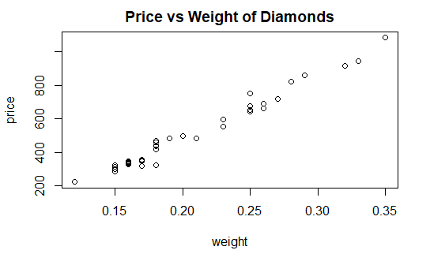

```r
library(s20x)
data(diamonds.df)
plot(price~weight, main = "Price vs Weight of Diamonds", data = diamonds.df)
```

```r
diamonds.fit = lm(price~weight, data = diamonds.df)
```

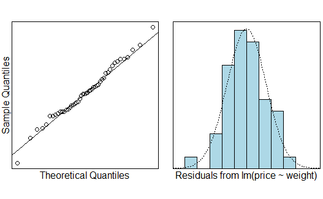

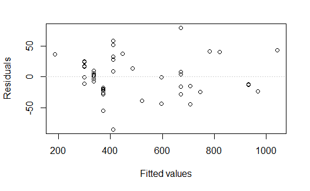

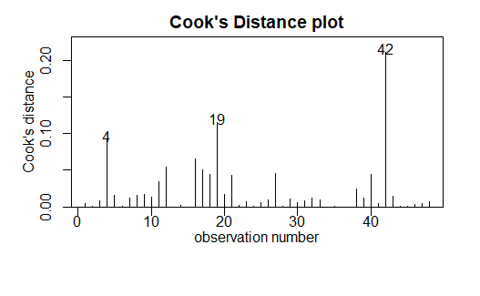

```r
confint(diamonds.fit)
```

```
               2.5 %    97.5 %
(Intercept) -294.487 -224.7649
weight      3556.398 3885.6513
```

```r
summary(diamonds.fit)
```

```
Call:
lm(formula = price ~ weight, data = diamonds.df)

Residuals:
    Min      1Q  Median      3Q     Max
-85.159 -21.448  -0.869  18.972  79.370

Coefficients:
            Estimate Std. Error t value Pr(>|t|)
(Intercept)  -259.63      17.32  -14.99   <2e-16 ***
weight       3721.02      81.79   45.50   <2e-16 ***
---
Signif. codes:  0 ‘***’ 0.001 ‘**’ 0.01 ‘*’ 0.05 ‘.’ 0.1 ‘ ’ 1

Residual standard error: 31.84 on 46 degrees of freedom
Multiple R-squared:  0.9783,    Adjusted R-squared:  0.9778
F-statistic:  2070 on 1 and 46 DF,  p-value: < 2.2e-16
```

```r
predict(diamonds.fit, pred, interval="prediction")
```

```
        fit       lwr       upr
1  856.6815  790.0316  923.3315
2 4205.6039 4029.3376 4381.8702
```

**Methods and Assumptions**

The price seems to be linearly changing with the weight of the diamonds, so we use a linear model.

There were no observable outliers in our Cook’s plot so no data points are removed.

The data is modelled using pricei = B0 + B1 * weighti + ei where ei ~iid N(0, sd^2).

**Executive Summary**

We are interested in finding a model between diamond ring prices and their diamond weights in Singaporean retialers based on data collected by lecturer few year ago.

There is a strong positive association between the weight of the diamond and the price of the ring - the heavier the diamond, the higher the price of the ring.

Our model explains 98% of the variance so it is a really good model for predictions.

We estimate the price for a 0.3 carat diamond ring to be between 790 SGD and 923 SGD.

Our data only has diamond rings weighing up to 0.35 carats so we cannot rely on the predictions for the 1.2 carat-ring.